# Demystifying R Survey Report

# About our Respondents

## Age

Respondents listed their age. The youngest respondent was 12 years old and the oldest respondent was 58. The mean age was 31.6.

The graph belows shows the age of respondents broken into three groups.

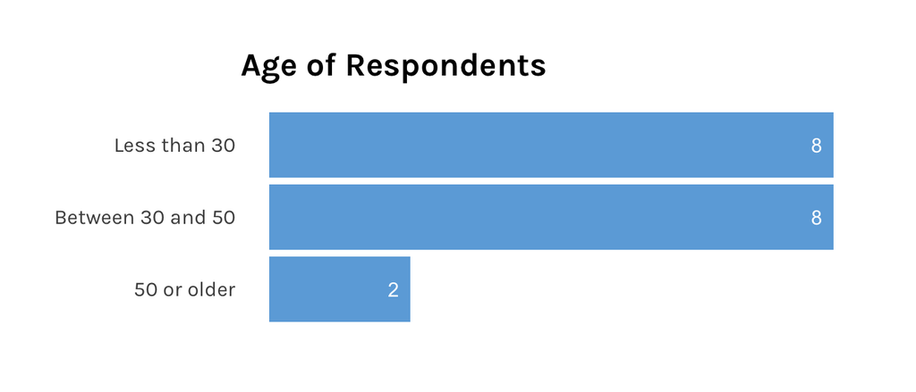

## Education

The education levels of respondents are below.

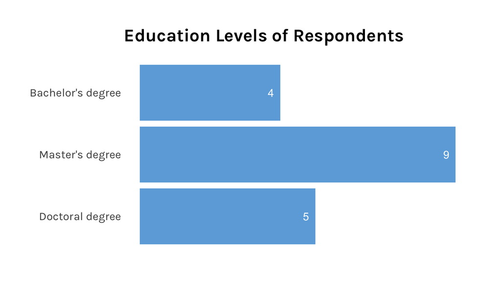

## Locations

Respondents listed the location of their primary residence. The map below shows their locations.

[interactive chart not shown]

## Gender

Respondents were asked to list their gender, in whatever form they choose to identify it.

The original responses are below.

| Gender (Original Response) |
| --- |
| Boy |
| Boy |
| Boy |
| Queer |
| Female |
| Female |
| female |
| Female |
| female |
| Female |

[output cut: 7 more lines]

The table below shows a summary of all responses.

| Gender (Original Response) | Number of Responses |
| --- | --- |
| Boy | 3 |
| female | 5 |
| Female | 8 |
| Queer | 1 |

We then used the [gendercodeR package](https://github.com/ropenscilabs/gendercoder) to recode responses. The table below shows the original responses and the recoded responses.

| Original Responses | Recoded Gender |
| --- | --- |
| Boy | Male |
| Boy | Male |
| Boy | Male |
| Queer | Unable to recode |
| Female | Female |
| Female | Female |
| female | Female |
| Female | Female |
| female | Female |
| Female | Female |

[output cut: 7 more lines]

We can then summarize the recoded responses, which we do in the following table.

| Recoded Gender | Number of Responses |
| --- | --- |
| Female | 13 |
| Male | 3 |
| Unable to recode | 1 |

# Familiarity with R

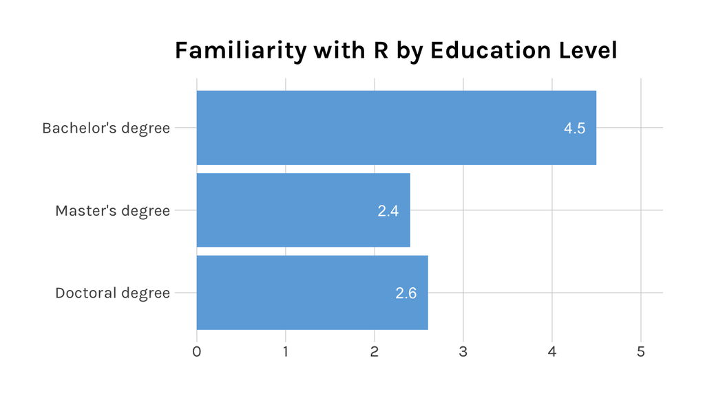

# Interest in Learning R

On a 5-point scale, respondents listed their level of interest in learning R as 4.5.

We can do a similar breakdown, but adding age. With one line of code, we can make small multiples.

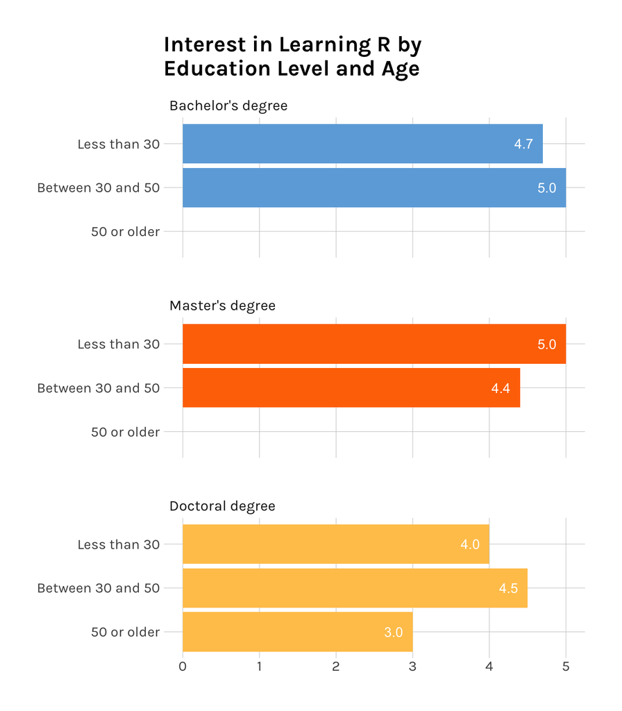